# 5-Intro_Stats

CM Gienger

30 October 2020

Note error between GardenOzone.csv and ozone.csv input files Known issue

`r`r # Check it out glimpse(lady)

```
Observations: 20
Variables: 4
$ Habitat      <fct> Rural, Rural, Rural, Rural, Rural, Rural, Rural, Rural, Rural, Rural, Industrial, Industrial, Ind…
$ Site         <fct> R1, R2, R3, R4, R5, R1, R2, R3, R4, R5, U1, U2, U3, U4, U5, U1, U2, U3, U4, U5
$ morph_colour <fct> black, black, black, black, black, red, red, red, red, red, black, black, black, black, black, re…
$ number       <int> 10, 3, 4, 7, 6, 15, 18, 9, 12, 16, 32, 25, 25, 17, 16, 17, 23, 21, 9, 15
```

`r`r #organize data for plotting/analysis

totals <- lady %>% group_by(Habitat, morph_colour) %>% summarise(total.number = sum(number))

totals

| Habitat | morph_colour | total.number |
| --- | --- | --- |
| Industrial | black | 115 |
| Industrial | red | 85 |
| Rural | black | 30 |
| Rural | red | 70 |

`r`r ggplot(totals, aes(x = Habitat, y = total.number, fill = morph_colour)) + geom_bar(stat = ‘identity’, position = ‘dodge’)

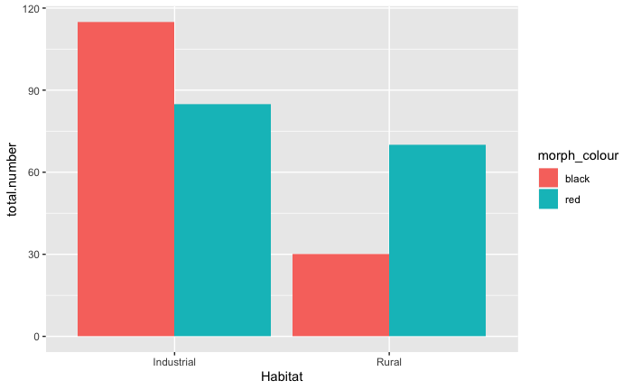

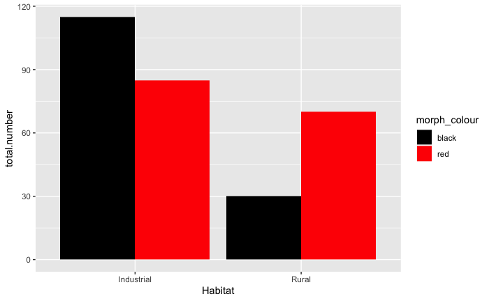

`r`r #Making the χ2 Test totals

| Habitat | morph_colour | total.number |
| --- | --- | --- |
| Industrial | black | 115 |
| Industrial | red | 85 |
| Rural | black | 30 |
| Rural | red | 70 |

`r`r lady.mat <- xtabs(number ~ Habitat + morph_colour, data = lady) lady.mat

```
            morph_colour
Habitat      black red
  Industrial   115  85
  Rural         30  70
```

`r`r chisq.test(lady.mat)

```
    Pearson's Chi-squared test with Yates' continuity correction

data:  lady.mat
X-squared = 19.103, df = 1, p-value = 1.239e-05
```

```
Observations: 20
Variables: 3
$ Ozone           <dbl> 61.7, 64.0, 72.4, 56.8, 52.4, 44.8, 70.4, 67.6, 68.8, 53.7, 59.1, 78.5, 73.9, 86.1, 78.0, 84.4…
$ Garden.location <fct> West, West, West, West, West, West, West, West, West, West, East, East, East, East, East, East…
$ Garden.ID       <fct> G1, G2, G3, G4, G5, G6, G7, G8, G9, G10, G11, G12, G13, G14, G15, G16, G17, G18, G19, G20
```

`r`r ggplot(ozone, aes(x = Ozone)) + geom_histogram(binwidth = 10) + facet_wrap(~ Garden.location, ncol = 1) + theme_bw()

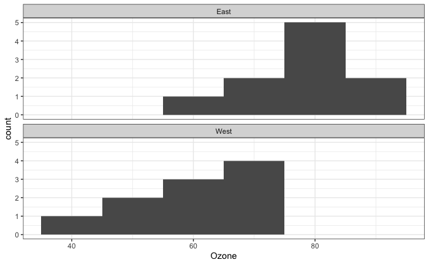

`r`r ggplot(ozone, aes(x = Garden.location, y = Ozone, color = Garden.location)) + geom_point(size=3) + theme_bw()

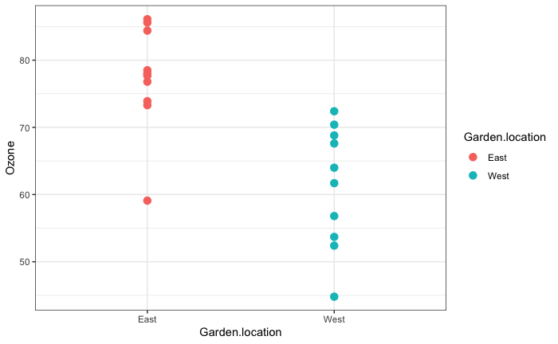

`r`r # Do a t.test now…. t.test(Ozone ~ Garden.location, data = ozone)

```
    Welch Two Sample t-test

data:  Ozone by Garden.location
t = 4.2363, df = 17.656, p-value = 0.0005159
alternative hypothesis: true difference in means is not equal to 0
95 percent confidence interval:
  8.094171 24.065829
sample estimates:
mean in group East mean in group West
             77.34              61.26
```